# Precautions and Tools for Alzheimer’s Safety

Published

May 26, 2024

# Precautions and Tools for Alzheimer’s Safety

1. **Alarmas y Alertas para Puertas:**
   - **Sensores de Puerta:** Instala alarmas en la puerta que te alerten cuando se abra. Estas pueden ser inalámbricas y activar un timbre o alarma cuando la puerta se abre.

     [Enlace - Amazon](https://a.co/d/8eJfpEB)

[figure not shown]

   - **Sensores de Movimiento:** Coloca sensores de movimiento cerca de la puerta para detectar movimiento y alertarte si alguien se acerca a la puerta.

     [Enlace - Amazon](https://a.co/d/1s4OEYe)

[figure not shown]

2. **Cerraduras y Seguridad:**
   - **Cerraduras en Posición Alta:** Instala cerraduras más altas en la puerta, fuera del campo de visión y alcance de tu abuela. Un cerrojo deslizante pueden ser efectivos.

     [Enlace - Amazon](https://a.co/d/9bN0bzE)

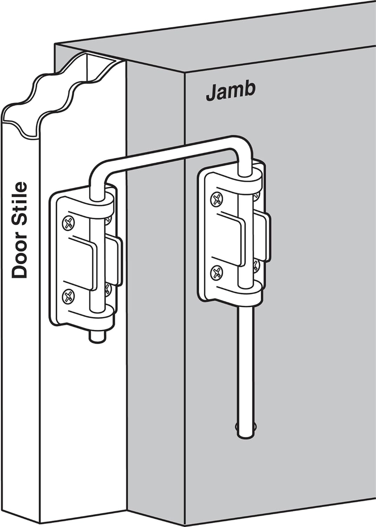

3. **Herramientas de Monitoreo:**
   - **Cámaras:** Usa cámaras de seguridad con acceso a transmisión en vivo para que puedas monitorear la entrada y recibir alertas si intenta salir.

     [Enlace - Amazon](https://a.co/d/bgLRRiz)

[figure not shown]

   - **Rastreadores GPS Portátiles:** Equípala con un rastreador GPS portátil para que puedas localizarla rápidamente si logra salir.

     [Enlace - Amazon](https://a.co/d/aToadyD)

[figure not shown]

[figure not shown]

4. **Modificaciones Ambientales:**
   - **Cubiertas para Puertas:** Coloca una cortina o cubierta sobre la puerta para hacerla menos obvia.

     [Enlace - Amazon](https://a.co/d/eBnm2nz)

[figure not shown]

   - **Señales Visuales:** Usa señales visuales como letreros de “STOP” o elementos decorativos que desanimen a acercarse a la puerta.

     [Enlace - Amazon](https://a.co/d/7sxbU2s)

[figure not shown]